# Моделирование и анализ графов атак

Лабораторная работа № 3

Бердыев Эзиз

1032255390@rudn.ru

Российский университет дружбы народов

2026-09-04

# Информация

## Докладчик

- Бердыев Эзиз
- студент группы НФИмд-01-25
- Российский университет дружбы народов им. П. Лумумбы
- 1032255390@rudn.ru

# Вводная часть

## Актуальность

- Злоумышленник редко атакует цель напрямую — он движется по цепочке узлов.
- Перечислить все сценарии вручную невозможно уже для небольшой сети.
- Графовая модель позволяет формализовать процесс проникновения и выделить узлы, защита которых даёт наибольший эффект.

## Объект и предмет исследования

- **Объект** — процесс проникновения злоумышленника в сетевую инфраструктуру.
- **Предмет** — графовая модель атак, алгоритмы поиска путей и метрики выявления критических узлов.

## Цели и задачи

**Цель** — изучить методы построения и анализа графов атак для оценки защищённости сетевой инфраструктуры.

**Задачи:**

- построить граф атак и найти все пути атаки;
- вычислить метрики центральности и выявить критические узлы;
- оценить вероятность успешной атаки;
- исследовать масштабируемость и влияние плотности сети.

## Материалы и методы

- Язык Julia [1], пакет Graphs.jl;
- модель графов атак [2,3];
- метрики центральности [4,5];
- оценки уязвимостей CVSS [6].

# Основная часть

## Модель графа атак

- Вершины — состояния системы (узлы сети).
- Рёбра — возможные действия злоумышленника.
- Отдельно вводятся **доверительные отношения** — связи, которыми злоумышленник может воспользоваться гарантированно.

## Поиск путей и вероятность атаки

Вероятность пути — произведение вероятностей рёбер:

$$P(\pi) = \prod_{(i,j) \in \pi} p_{ij} .$$

Логарифмирование сводит максимизацию произведения к минимизации суммы:

$$\arg\max_{\pi} \prod p_{ij}
= \arg\min_{\pi} \sum \bigl(-\ln p_{ij}\bigr) .$$

Веса неотрицательны — применим алгоритм Дейкстры.

## Визуализация графа

[figure not shown]

Рис. 1: Граф атак с цветовой шкалой по центральности

## Результат основного эксперимента

Табл. 1: Результаты эксперимента

| Характеристика | Значение |
| --- | --- |
| Число узлов / рёбер | 20 / 66 |
| Число простых путей из узла 1 в 20 | 1814 |
| Наиболее вероятный путь | 1 → 7 → 20 |
| Вероятность этого пути | 0.25 |

Из 1814 путей наиболее вероятен самый короткий: каждый лишний переход уменьшает произведение вероятностей.

## Критические узлы

Табл. 2: Топ узлов по метрикам центральности

| Узел | in-degree | betweenness | PageRank |
| --- | --- | --- | --- |
| 11 | 7 | 0.193 | 0.1484 |
| 4 | 6 | 0.097 | 0.1144 |
| 6 | 4 | 0.304 | 0.1113 |
| 5 | 7 | 0.267 | 0.0985 |

Метрики упорядочивают узлы **по-разному**: узел 6 при вдвое меньшем in-degree лидирует по betweenness — он лежит на доверительных связях.

## Масштабируемость

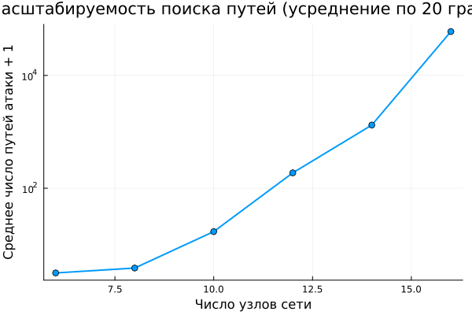

Рис. 2: Рост числа путей атаки с размером сети, логарифмическая шкала

Усреднение по 20 графам: с 6 до 16 узлов число путей растёт с 2 до 60 000.

## Влияние плотности сети

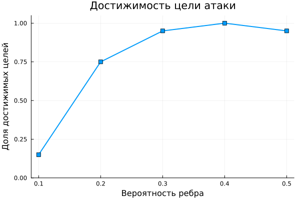

Рис. 3: Доля сетей, в которых цель достижима из точки входа

Достижимость выходит на насыщение уже при $p \approx 0.3$.

# Результаты

## Полученные результаты

- Реализованы построение графа, поиск всех путей (DFS), метрики центральности и поиск наиболее вероятного пути.
- В основном эксперименте найдено 1814 путей атаки.
- Показано, что разные метрики центральности дают разные упорядочения узлов.
- Подтверждён экспоненциальный рост числа путей: с 6 до 16 узлов — примерно в 28 тысяч раз.
- Код преобразован в литературный стиль.

## Ограничения модели

- Модель статична: не учитывает действия защитника и изменение состояния узлов после компрометации.
- Вероятности рёбер считаются независимыми.
- Полный перебор путей неосуществим для реальных сетей.

## Итоговый слайд

- Графы атак эффективно формализуют сценарии проникновения.
- Прямое перечисление путей неприменимо к реальным сетям — растёт экспоненциально.
- Практическую ценность имеют метрики центральности: они выделяют критические узлы без построения всех путей.

## Список литературы

1.

Bezanson J. и др. [Julia: A Fresh Approach to Numerical Computing](https://doi.org/10.1137/141000671) // SIAM Review. 2017. Т. 59, № 1. С. 65–98.

2.

Phillips C., Swiler L. P. [A Graph-Based System for Network-Vulnerability Analysis](https://doi.org/10.1145/310889.310919) // Proceedings of the 1998 Workshop on New Security Paradigms (NSPW ’98). 1998. С. 71–79.

3.

Sheyner O. и др. [Automated Generation and Analysis of Attack Graphs](https://doi.org/10.1109/SECPRI.2002.1004377) // Proceedings of the 2002 IEEE Symposium on Security and Privacy. 2002. С. 273–284.

4.

Freeman L. C. [A Set of Measures of Centrality Based on Betweenness](https://doi.org/10.2307/3033543) // Sociometry. 1977. Т. 40, № 1. С. 35–41.

5.

Page L. и др. The PageRank Citation Ranking: Bringing Order to the Web: 1999-66. Stanford InfoLab, 1999.

6.

Forum of Incident Response and Security Teams. [Common Vulnerability Scoring System version 3.1: Specification Document](https://www.first.org/cvss/v3.1/specification-document). 2019.